# Description

## Model building - Decision Tree, Random Forest, Bagging and Boosting Classifier.

- Build Decision Tree, Random Forest, Bagging and Boosting classifier.

```python
X = df.drop("ProdTaken", axis=1)
y = df.pop("ProdTaken")
```

```python
# Encoding categorical features
for col in X.select_dtypes(include=["category"]).columns:
    X[col] = X[col].cat.codes

X_train, X_test, y_train, y_test = train_test_split(
    X, y, test_size=0.30, random_state=1, stratify=y
)
```

```python
print(X_train.shape, X_test.shape)
```

```
(3137, 18) (1345, 18)
```

**The Stratify arguments maintains the original distribution of classes in the target variable while splitting the data into train and test sets.**

```python
y.value_counts(1)
```

```
0    0.807898
1    0.192102
Name: ProdTaken, dtype: float64
```

```python
y_test.value_counts(1)
```

```
0    0.808178
1    0.191822
Name: ProdTaken, dtype: float64
```

```python
X.head()
```

|  | Age | TypeofContact | CityTier | DurationOfPitch | Occupation | Gender | NumberOfPersonVisiting | NumberOfFollowups | ProductPitched | PreferredPropertyStar | MaritalStatus | NumberOfTrips | Passport | PitchSatisfactionScore | OwnCar | NumberOfChildrenVisiting | Designation | MonthlyIncome |
| --- | --- | --- | --- | --- | --- | --- | --- | --- | --- | --- | --- | --- | --- | --- | --- | --- | --- | --- |
| 0 | 41.0 | 1 | 2 | 6.0 | 1 | 2 | 2 | 2 | 2 | 0 | 3 | 0 | 1 | 1 | 1 | 0 | 1 | 20993.0 |
| 1 | 49.0 | 2 | 0 | 14.0 | 1 | 1 | 2 | 3 | 2 | 1 | 2 | 1 | 0 | 2 | 1 | 2 | 1 | 20130.0 |
| 2 | 37.0 | 1 | 0 | 8.0 | 4 | 1 | 2 | 3 | 1 | 0 | 3 | 6 | 1 | 2 | 0 | 0 | 0 | 17090.0 |
| 3 | 33.0 | 2 | 0 | 9.0 | 1 | 2 | 1 | 2 | 1 | 0 | 2 | 1 | 1 | 4 | 1 | 1 | 0 | 17909.0 |
| 5 | 32.0 | 2 | 0 | 8.0 | 1 | 1 | 2 | 2 | 1 | 0 | 3 | 0 | 0 | 4 | 1 | 1 | 0 | 18068.0 |

## Model evaluation criterion

### Model can make wrong predictions as:

1. Predicting a customer doesn't purchase a travel package and the person actually getting a travel package.
2. Predicting a customer does purchase a travel package and the person actually is not getting a travel package.

### Which case is more important?

- Predicting a customer doesn't purchase a travel package and the person actually getting a travel package.

### Which metric to optimize?

- We want Recall to be maximized, the greater the Recall higher the chances of minimizing false negatives.
- If a model predicts that a customer will purchase a package and in reality, customer doesn't purchase then it is just a waste of marketing effort and expense.
- However, if we predict that a customer will not buy a package but the customer actually willing to buy, this would lead to loss of revenue which is far worse than marketing expense.
- Losing a customer is much worse than marketing expense.

```python
## Function to create confusion matrix
def make_confusion_matrix(model, y_actual, labels=[1, 0]):
    """
    model : classifier to predict values of X
    y_actual : ground truth

    """
    y_predict = model.predict(X_test)
    cm = metrics.confusion_matrix(y_actual, y_predict, labels=[0, 1])
    df_cm = pd.DataFrame(
        cm,
        index=[i for i in ["Actual - No", "Actual - Yes"]],
        columns=[i for i in ["Predicted - No", "Predicted - Yes"]],
    )
    group_counts = ["{0:0.0f}".format(value) for value in cm.flatten()]
    group_percentages = ["{0:.2%}".format(value) for value in cm.flatten() / np.sum(cm)]
    labels = [f"{v1}\n{v2}" for v1, v2 in zip(group_counts, group_percentages)]
    labels = np.asarray(labels).reshape(2, 2)
    plt.figure(figsize=(10, 7))
    sns.heatmap(df_cm, annot=labels, fmt="")
    plt.ylabel("True label")
    plt.xlabel("Predicted label")
```

```python
##  Function to calculate different metric scores of the model - Accuracy, Recall and Precision
def get_metrics_score(model, flag=True):
    """
    model : classifier to predict values of X

    """
    # defining an empty list to store train and test results
    score_list = []

    # Predicting on train and tests
    pred_train = model.predict(X_train)
    pred_test = model.predict(X_test)

    # Accuracy of the model
    train_acc = model.score(X_train, y_train)
    test_acc = model.score(X_test, y_test)

    # Recall of the model
    train_recall = metrics.recall_score(y_train, pred_train)
    test_recall = metrics.recall_score(y_test, pred_test)

    # Precision of the model
    train_precision = metrics.precision_score(y_train, pred_train)
    test_precision = metrics.precision_score(y_test, pred_test)

    # F1-Score of the model
    train_f1_score = metrics.f1_score(y_train, pred_train)
    test_f1_score = metrics.f1_score(y_test, pred_test)

    score_list.extend(
        (
            train_acc,
            test_acc,
            train_recall,
            test_recall,
            train_precision,
            test_precision,
            train_f1_score,
            test_f1_score,
        )
    )

    # If the flag is set to True then only the following print statements will be dispayed. The default value is set to True.
    if flag == True:
        print("Accuracy on training set : ", model.score(X_train, y_train))
        print("Accuracy on test set : ", model.score(X_test, y_test))
        print("Recall on training set : ", metrics.recall_score(y_train, pred_train))
        print("Recall on test set : ", metrics.recall_score(y_test, pred_test))
        print(
            "Precision on training set : ", metrics.precision_score(y_train, pred_train)
        )
        print("Precision on test set : ", metrics.precision_score(y_test, pred_test))
        print("F1 Score on test set : ", metrics.f1_score(y_test, pred_test))
        print("F1 Score on train set : ", metrics.f1_score(y_test, pred_test))

    return score_list  # returning the list with train and test scores
```

## Decision Tree

```
Accuracy on training set :  1.0
Accuracy on test set :  0.9055762081784386
Recall on training set :  1.0
Recall on test set :  0.7751937984496124
Precision on training set :  1.0
Precision on test set :  0.7434944237918215
F1 Score on test set :  0.7590132827324478
F1 Score on train set :  0.7590132827324478
```

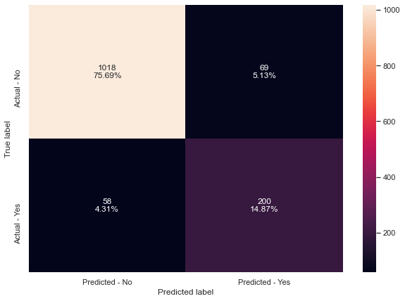

```python
# Fitting the model
d_tree = DecisionTreeClassifier(random_state=1)
d_tree.fit(X_train, y_train)

# Calculating different metrics
get_metrics_score(d_tree)

# Creating confusion matrix
make_confusion_matrix(d_tree, y_test)
```

### Observation - Decision tree with default parameters

- Decision tree model with default parameters overfits the train data.

### Hyperparameter Tuning

```python
# Choose the type of classifier.
dtree_estimator = DecisionTreeClassifier(
    class_weight={0: 0.18, 1: 0.72}, random_state=1
)

# Grid of parameters to choose from
parameters = {
    "max_depth": np.arange(2, 30),
    "min_samples_leaf": [1, 2, 5, 7, 10],
    "max_leaf_nodes": [2, 3, 5, 10, 15],
    "min_impurity_decrease": [0.0001, 0.001, 0.01, 0.1],
}

# Type of scoring used to compare parameter combinations
scorer = metrics.make_scorer(metrics.f1_score)

# Run the grid search
grid_obj = GridSearchCV(dtree_estimator, parameters, scoring=scorer, n_jobs=-1)
grid_obj = grid_obj.fit(X_train, y_train)

# Set the clf to the best combination of parameters
dtree_estimator = grid_obj.best_estimator_

# Fit the best algorithm to the data.
dtree_estimator.fit(X_train, y_train)
```

```
DecisionTreeClassifier(class_weight={0: 0.18, 1: 0.72}, max_depth=5,
                       max_leaf_nodes=15, min_impurity_decrease=0.0001,
                       min_samples_leaf=10, random_state=1)
```

```
Accuracy on training set :  0.7765380937201147
Accuracy on test set :  0.7516728624535316
Recall on training set :  0.7197346600331676
Recall on test set :  0.6627906976744186
Precision on training set :  0.4492753623188406
Precision on test set :  0.4090909090909091
F1 Score on test set :  0.5059171597633136
F1 Score on train set :  0.5059171597633136
```

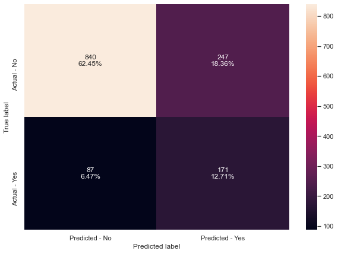

```python
get_metrics_score(dtree_estimator)

make_confusion_matrix(dtree_estimator, y_test)
```

### Observation - Decision tree after hyper tuning

- Decision tree model after hyper tuning is not overfitting the train data. Training and testing metrics are close to each other.
- All three metrics (Accuracy, Recall and Precision) are performing worse after tuning.

```python
# defining list of models
models = [
    d_tree,
    dtree_estimator,
]

# defining empty lists to add train and test results
acc_train = []
acc_test = []
recall_train = []
recall_test = []
precision_train = []
precision_test = []

# looping through all the models to get the accuracy, precall and precision scores
for model in models:
    j = get_metrics_score(model, False)
    acc_train.append(np.round(j[0], 2))
    acc_test.append(np.round(j[1], 2))
    recall_train.append(np.round(j[2], 2))
    recall_test.append(np.round(j[3], 2))
    precision_train.append(np.round(j[4], 2))
    precision_test.append(np.round(j[5], 2))
```

```python
comparison_frame = pd.DataFrame(
    {
        "Model": [
            "Decision Tree with default parameters",
            "Tuned Decision Tree",
        ],
        "Train_Accuracy": acc_train,
        "Test_Accuracy": acc_test,
        "Train_Recall": recall_train,
        "Test_Recall": recall_test,
        "Train_Precision": precision_train,
        "Test_Precision": precision_test,
    }
)
comparison_frame
```

|  | Model | Train_Accuracy | Test_Accuracy | Train_Recall | Test_Recall | Train_Precision | Test_Precision |
| --- | --- | --- | --- | --- | --- | --- | --- |
| 0 | Decision Tree with default parameters | 1.00 | 0.91 | 1.00 | 0.78 | 1.00 | 0.74 |
| 1 | Tuned Decision Tree | 0.78 | 0.75 | 0.72 | 0.66 | 0.45 | 0.41 |

## Ensemble Bagging

### Bagging Classifier

```python
# base_estimator for bagging classifier is a decision tree by default
bagging_estimator = BaggingClassifier(random_state=1)
bagging_estimator.fit(X_train, y_train)
```

```
BaggingClassifier(random_state=1)
```

```python
bagging_estimator_score = get_metrics_score(bagging_estimator)
```

```
Accuracy on training set :  0.9945808096907873
Accuracy on test set :  0.9011152416356877
Recall on training set :  0.9718076285240465
Recall on test set :  0.6085271317829457
Precision on training set :  1.0
Precision on test set :  0.8306878306878307
F1 Score on test set :  0.7024608501118569
F1 Score on train set :  0.7024608501118569
```

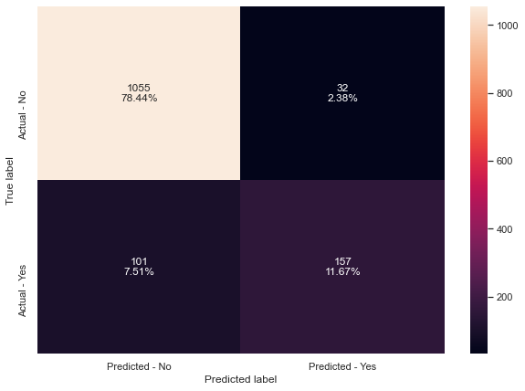

```python
make_confusion_matrix(bagging_estimator, y_test)
```

### Observation - Bagging Classifier

- Bagging classifier overfits the training data as train precision and recall are much higher than the test precision and test recall.
- Model is good at predicting non-purchasers than purchasers.

### Logistic regression as the base estimator for bagging classifier:

```python
bagging_lr = BaggingClassifier(
    base_estimator=LogisticRegression(random_state=1), random_state=1
)
bagging_lr.fit(X_train, y_train)
```

```
BaggingClassifier(base_estimator=LogisticRegression(random_state=1),
                  random_state=1)
```

```python
# Using above defined function to get accuracy, recall and precision on train and test set
bagging_lr_score = get_metrics_score(bagging_lr)
```

```
Accuracy on training set :  0.8342365317182021
Accuracy on test set :  0.8319702602230483
Recall on training set :  0.21227197346600332
Recall on test set :  0.18604651162790697
Precision on training set :  0.7398843930635838
Precision on test set :  0.75
F1 Score on test set :  0.2981366459627329
F1 Score on train set :  0.2981366459627329
```

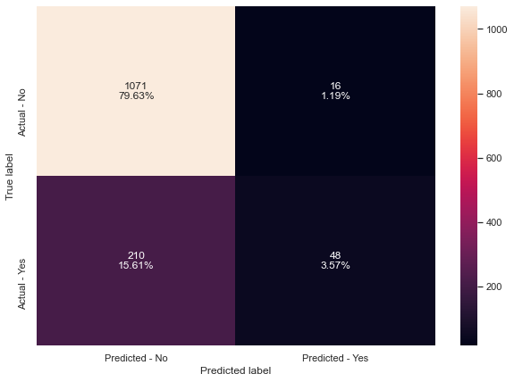

```python
make_confusion_matrix(bagging_lr, y_test)
```

### Observation - Bagging Classifier with logistic regression as the base estimator

- Bagging classifier with LR doesn't overfits the training data as train metrics are similar to test precision and test recall.
- Model recall metrics is very poor as more customer are falsely predicted as non-purchasers.

### Random Forest Classifier

```python
# Train the random forest classifier
rf_estimator = RandomForestClassifier(random_state=1)
rf_estimator.fit(X_train, y_train)
```

```
RandomForestClassifier(random_state=1)
```

```python
# Using above defined function to get accuracy, recall and precision on train and test set
rf_estimator_score = get_metrics_score(rf_estimator)
```

```
Accuracy on training set :  1.0
Accuracy on test set :  0.9211895910780669
Recall on training set :  1.0
Recall on test set :  0.627906976744186
Precision on training set :  1.0
Precision on test set :  0.9418604651162791
F1 Score on test set :  0.7534883720930232
F1 Score on train set :  0.7534883720930232
```

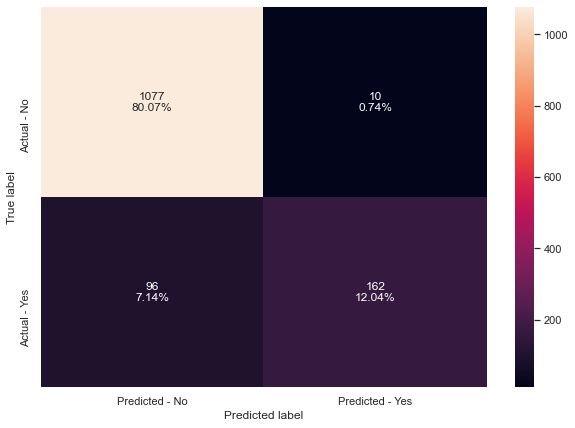

```python
make_confusion_matrix(rf_estimator, y_test)
```

### Observation - Random Classifier

- Random classifier overfits the training data as train precision and recall are much higher than the test precision and test recall.

## Model performance improvement

### Bagging Classifier

Important hyper-parameters used for tuning bagging classifier:

- n_estimators: The number of trees in the forest, default = 100.
- max_features: The number of features to consider when looking for the best split.
- max_samples: If bootstrap is True, then the number of samples to draw from X to train each base estimator. If None (default), then draw N samples, where N is the number of observations in the train data.

```python
# Choose the type of classifier.
bagging_estimator_tuned = BaggingClassifier(random_state=1)

# Grid of parameters to choose from
## add from article
parameters = {
    "max_samples": [0.7, 0.8, 0.9, 1],
    "max_features": [0.7, 0.8, 0.9, 1],
    "n_estimators": [10, 20, 30, 40, 50],
}

# Type of scoring used to compare parameter combinations
acc_scorer = metrics.make_scorer(metrics.recall_score)

# Run the grid search
grid_obj = GridSearchCV(bagging_estimator_tuned, parameters, scoring=acc_scorer, cv=5)
grid_obj = grid_obj.fit(X_train, y_train)

# Set the clf to the best combination of parameters
bagging_estimator_tuned = grid_obj.best_estimator_

# Fit the best algorithm to the data.
bagging_estimator_tuned.fit(X_train, y_train)
```

```
BaggingClassifier(max_features=0.9, max_samples=0.9, n_estimators=50,
                  random_state=1)
```

```python
# Using above defined function to get accuracy, recall and precision on train and test set
bagging_estimator_tuned_score = get_metrics_score(bagging_estimator_tuned)
```

```
Accuracy on training set :  0.9990436722983742
Accuracy on test set :  0.9130111524163569
Recall on training set :  0.9950248756218906
Recall on test set :  0.6356589147286822
Precision on training set :  1.0
Precision on test set :  0.8770053475935828
F1 Score on test set :  0.7370786516853933
F1 Score on train set :  0.7370786516853933
```

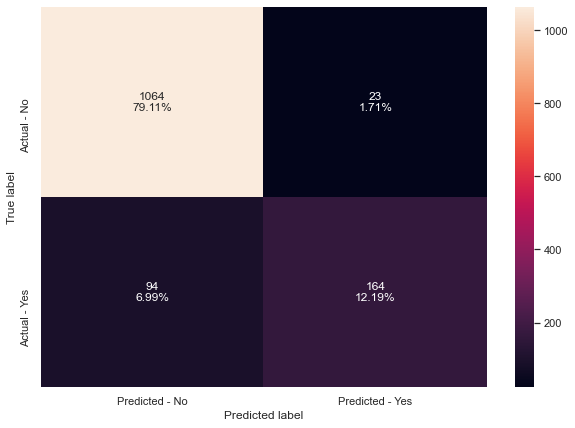

```python
make_confusion_matrix(bagging_estimator_tuned, y_test)
```

### Observation - Bagging Classifier after hyper-parameter tuning.

- After hyper-parameter tuning, Bagging classifier performs better than default parameters.
- However this still overfits the training data.

### Random Forest Classifier

Important hyper-parameters used for tuning Random forest classifier:

- n_estimators: The number of trees in the forest, default = 100.
- max_features: The number of features to consider when looking for the best split.
- max_samples: If bootstrap is True, then the number of samples to draw from X to train each base estimator. If None (default), then draw N samples, where N is the number of observations in the train data.
- min_samples_leaf: The minimum number of samples required to be at a leaf node.

```python
# Choose the type of classifier.
rf_estimator_tuned = RandomForestClassifier(random_state=1)

# Grid of parameters to choose from
## add from article
parameters = {
    "n_estimators": [20, 40, 60, 80],
    "min_samples_leaf": np.arange(5, 10),
    "max_features": np.arange(0.2, 0.7, 0.1),
    "max_samples": np.arange(0.3, 0.7, 0.1),
}

# Type of scoring used to compare parameter combinations
acc_scorer = metrics.make_scorer(metrics.recall_score)

# Run the grid search
grid_obj = GridSearchCV(rf_estimator_tuned, parameters, scoring=acc_scorer, cv=5)
grid_obj = grid_obj.fit(X_train, y_train)

# Set the clf to the best combination of parameters
rf_estimator_tuned = grid_obj.best_estimator_

# Fit the best algorithm to the data.
rf_estimator_tuned.fit(X_train, y_train)
```

```
RandomForestClassifier(max_features=0.6000000000000001,
                       max_samples=0.6000000000000001, min_samples_leaf=5,
                       n_estimators=60, random_state=1)
```

```python
# Using above defined function to get accuracy, recall and precision on train and test set
rf_estimator_tuned_score = get_metrics_score(rf_estimator_tuned)
```

```
Accuracy on training set :  0.9161619381574753
Accuracy on test set :  0.8736059479553904
Recall on training set :  0.5970149253731343
Recall on test set :  0.44573643410852715
Precision on training set :  0.9473684210526315
Precision on test set :  0.8098591549295775
F1 Score on test set :  0.5750000000000001
F1 Score on train set :  0.5750000000000001
```

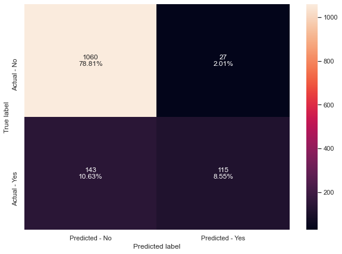

```python
make_confusion_matrix(rf_estimator_tuned, y_test)
```

### Observation - Random Classifier after hyper tuning

- Random classifier after tuning is less overfitting than default parameters model.
- However it performs poorly in all metrics.

### Class_weights for random forest:

Important hyper-parameters used for tuning Random forest classifier:

- class_weight: Weights associated with classes in the form {class_label: weight}
- n_estimators: The number of trees in the forest, default = 100.
- max_features: The number of features to consider when looking for the best split.
- max_samples: If bootstrap is True, then the number of samples to draw from X to train each base estimator. If None (default), then draw N samples, where N is the number of observations in the train data.
- min_samples_leaf: The minimum number of samples required to be at a leaf node.

```python
# Choose the type of classifier.
rf_estimator_weighted = RandomForestClassifier(random_state=1)

# Grid of parameters to choose from
## add from article
parameters = {
    "class_weight": [{0: 0.3, 1: 0.7}],
    "n_estimators": [20, 40, 60, 80],
    "min_samples_leaf": np.arange(5, 10),
    "max_features": np.arange(0.2, 0.7, 0.1),
    "max_samples": np.arange(0.3, 0.7, 0.1),
}

# Type of scoring used to compare parameter combinations
acc_scorer = metrics.make_scorer(metrics.recall_score)

# Run the grid search
grid_obj = GridSearchCV(rf_estimator_weighted, parameters, scoring=acc_scorer, cv=5)
grid_obj = grid_obj.fit(X_train, y_train)

# Set the clf to the best combination of parameters
rf_estimator_weighted = grid_obj.best_estimator_

# Fit the best algorithm to the data.
rf_estimator_weighted.fit(X_train, y_train)
```

```
RandomForestClassifier(class_weight={0: 0.3, 1: 0.7},
                       max_features=0.6000000000000001,
                       max_samples=0.6000000000000001, min_samples_leaf=7,
                       n_estimators=20, random_state=1)
```

```python
# Using above defined function to get accuracy, recall and precision on train and test set
rf_estimator_weighted_score = get_metrics_score(rf_estimator_weighted)
```

```
Accuracy on training set :  0.90532355753905
Accuracy on test set :  0.8646840148698884
Recall on training set :  0.7064676616915423
Recall on test set :  0.5658914728682171
Precision on training set :  0.7802197802197802
Precision on test set :  0.6759259259259259
F1 Score on test set :  0.6160337552742616
F1 Score on train set :  0.6160337552742616
```

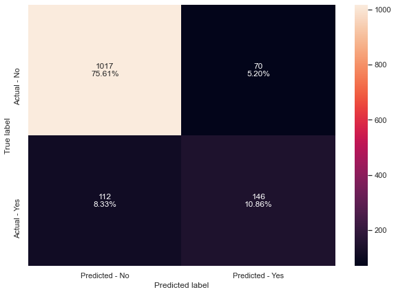

```python
make_confusion_matrix(rf_estimator_weighted, y_test)
```

### Observation - Random Forest Classifier with class weights.

- Random classifier with class weights is less overfitting than default parameters model.
- It performs better than RM tuned model but poorly when compared to default parameters model.

### Checking the feature importance

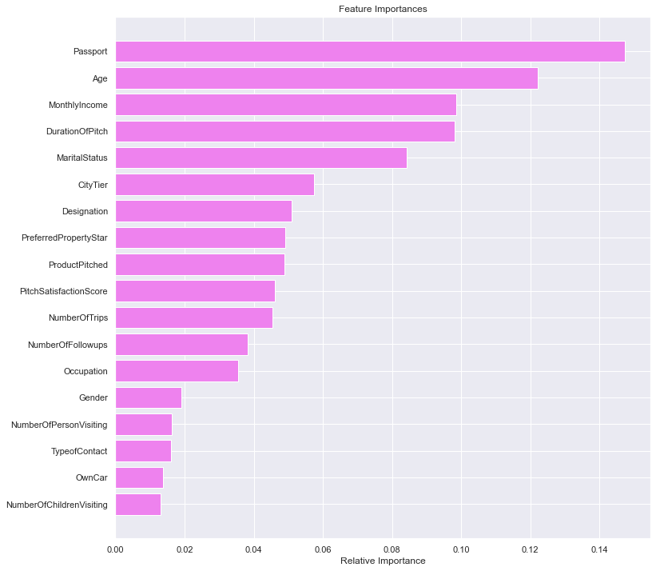

```python
importances = rf_estimator_weighted.feature_importances_
indices = np.argsort(importances)
feature_names = list(X.columns)

plt.figure(figsize=(12, 12))
plt.title("Feature Importances")
plt.barh(range(len(indices)), importances[indices], color="violet", align="center")
plt.yticks(range(len(indices)), [feature_names[i] for i in indices])
plt.xlabel("Relative Importance")
plt.show()
```

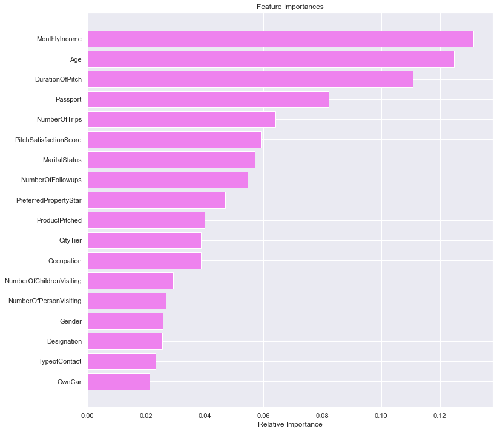

```python
importances = rf_estimator.feature_importances_
indices = np.argsort(importances)
feature_names = list(X.columns)

plt.figure(figsize=(12, 12))
plt.title("Feature Importances")
plt.barh(range(len(indices)), importances[indices], color="violet", align="center")
plt.yticks(range(len(indices)), [feature_names[i] for i in indices])
plt.xlabel("Relative Importance")
plt.show()
```

### Comparing all models, so far.

```python
# defining list of models
models = [
    d_tree,
    dtree_estimator,
    bagging_estimator,
    bagging_estimator_tuned,
    bagging_lr,
    rf_estimator,
    rf_estimator_tuned,
    rf_estimator_weighted,
]

# defining empty lists to add train and test results
acc_train = []
acc_test = []
recall_train = []
recall_test = []
precision_train = []
precision_test = []
f1Score_train = []
f1Score_test = []

# looping through all the models to get the accuracy, precall and precision scores
for model in models:
    j = get_metrics_score(model, False)
    acc_train.append(np.round(j[0], 2))
    acc_test.append(np.round(j[1], 2))
    recall_train.append(np.round(j[2], 2))
    recall_test.append(np.round(j[3], 2))
    precision_train.append(np.round(j[4], 2))
    precision_test.append(np.round(j[5], 2))
    f1Score_train.append(np.round(j[6], 2))
    f1Score_test.append(np.round(j[7], 2))
```

```python
comparison_frame = pd.DataFrame(
    {
        "Model": [
            "Decision Tree with default parameters",
            "Tuned Decision Tree",
            "Bagging classifier with default parameters",
            "Tuned Bagging Classifier",
            "Bagging classifier with base_estimator=LR",
            "Random Forest with deafult parameters",
            "Tuned Random Forest Classifier",
            "Random Forest with class_weights",
        ],
        "Train_Accuracy": acc_train,
        "Test_Accuracy": acc_test,
        "Train_Recall": recall_train,
        "Test_Recall": recall_test,
        "Train_Precision": precision_train,
        "Test_Precision": precision_test,
        "Train_F1Score": f1Score_train,
        "Test_F1Score": f1Score_test,
    }
)
comparison_frame
```

|  | Model | Train_Accuracy | Test_Accuracy | Train_Recall | Test_Recall | Train_Precision | Test_Precision | Train_F1Score | Test_F1Score |
| --- | --- | --- | --- | --- | --- | --- | --- | --- | --- |
| 0 | Decision Tree with default parameters | 1.00 | 0.91 | 1.00 | 0.78 | 1.00 | 0.74 | 1.00 | 0.76 |
| 1 | Tuned Decision Tree | 0.78 | 0.75 | 0.72 | 0.66 | 0.45 | 0.41 | 0.55 | 0.51 |
| 2 | Bagging classifier with default parameters | 0.99 | 0.90 | 0.97 | 0.61 | 1.00 | 0.83 | 0.99 | 0.70 |
| 3 | Tuned Bagging Classifier | 1.00 | 0.91 | 1.00 | 0.64 | 1.00 | 0.88 | 1.00 | 0.74 |
| 4 | Bagging classifier with base_estimator=LR | 0.83 | 0.83 | 0.21 | 0.19 | 0.74 | 0.75 | 0.33 | 0.30 |
| 5 | Random Forest with deafult parameters | 1.00 | 0.92 | 1.00 | 0.63 | 1.00 | 0.94 | 1.00 | 0.75 |
| 6 | Tuned Random Forest Classifier | 0.92 | 0.87 | 0.60 | 0.45 | 0.95 | 0.81 | 0.73 | 0.58 |
| 7 | Random Forest with class_weights | 0.91 | 0.86 | 0.71 | 0.57 | 0.78 | 0.68 | 0.74 | 0.62 |

```python
comparison_frame.sort_values(by=["Test_Recall", "Train_Recall"], ascending=False)
```

|  | Model | Train_Accuracy | Test_Accuracy | Train_Recall | Test_Recall | Train_Precision | Test_Precision | Train_F1Score | Test_F1Score |
| --- | --- | --- | --- | --- | --- | --- | --- | --- | --- |
| 0 | Decision Tree with default parameters | 1.00 | 0.91 | 1.00 | 0.78 | 1.00 | 0.74 | 1.00 | 0.76 |
| 1 | Tuned Decision Tree | 0.78 | 0.75 | 0.72 | 0.66 | 0.45 | 0.41 | 0.55 | 0.51 |
| 3 | Tuned Bagging Classifier | 1.00 | 0.91 | 1.00 | 0.64 | 1.00 | 0.88 | 1.00 | 0.74 |
| 5 | Random Forest with deafult parameters | 1.00 | 0.92 | 1.00 | 0.63 | 1.00 | 0.94 | 1.00 | 0.75 |
| 2 | Bagging classifier with default parameters | 0.99 | 0.90 | 0.97 | 0.61 | 1.00 | 0.83 | 0.99 | 0.70 |
| 7 | Random Forest with class_weights | 0.91 | 0.86 | 0.71 | 0.57 | 0.78 | 0.68 | 0.74 | 0.62 |
| 6 | Tuned Random Forest Classifier | 0.92 | 0.87 | 0.60 | 0.45 | 0.95 | 0.81 | 0.73 | 0.58 |
| 4 | Bagging classifier with base_estimator=LR | 0.83 | 0.83 | 0.21 | 0.19 | 0.74 | 0.75 | 0.33 | 0.30 |

## Model building - Build Adaboost, gradient boost, xgboost, and stacking classifier

### AdaBoost Classifier

```python
abc = AdaBoostClassifier(random_state=1)
abc.fit(X_train, y_train)
```

```
AdaBoostClassifier(random_state=1)
```

```python
# Using above defined function to get accuracy, recall and precision on train and test set
abc_score = get_metrics_score(abc)
```

```
Accuracy on training set :  0.8552757411539688
Accuracy on test set :  0.8356877323420074
Recall on training set :  0.3913764510779436
Recall on test set :  0.32170542635658916
Precision on training set :  0.7306501547987616
Precision on test set :  0.6434108527131783
F1 Score on test set :  0.42894056847545226
F1 Score on train set :  0.42894056847545226
```

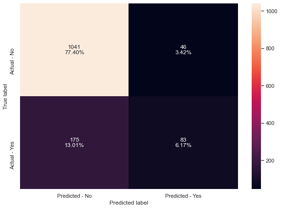

```python
make_confusion_matrix(abc, y_test)
```

### Gradient Boosting Classifier

```python
gbc = GradientBoostingClassifier(random_state=1)
gbc.fit(X_train, y_train)
```

```
GradientBoostingClassifier(random_state=1)
```

```python
# Using above defined function to get accuracy, recall and precision on train and test set
gbc_score = get_metrics_score(gbc)
```

```
Accuracy on training set :  0.8957602805227924
Accuracy on test set :  0.8587360594795539
Recall on training set :  0.5257048092868989
Recall on test set :  0.4069767441860465
Precision on training set :  0.8854748603351955
Precision on test set :  0.7394366197183099
F1 Score on test set :  0.525
F1 Score on train set :  0.525
```

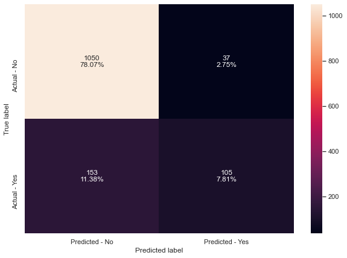

```python
make_confusion_matrix(gbc, y_test)
```

### XGBoost Classifier

```python
xgb = XGBClassifier(random_state=1, eval_metric="logloss")


xgb.fit(X_train, y_train)
```

```
XGBClassifier(base_score=0.5, booster='gbtree', colsample_bylevel=1,
              colsample_bynode=1, colsample_bytree=1, eval_metric='logloss',
              gamma=0, gpu_id=-1, importance_type='gain',
              interaction_constraints='', learning_rate=0.300000012,
              max_delta_step=0, max_depth=6, min_child_weight=1, missing=nan,
              monotone_constraints='()', n_estimators=100, n_jobs=8,
              num_parallel_tree=1, random_state=1, reg_alpha=0, reg_lambda=1,
              scale_pos_weight=1, subsample=1, tree_method='exact',
              validate_parameters=1, verbosity=None)
```

```python
# Using above defined function to get accuracy, recall and precision on train and test set
xgb_score = get_metrics_score(xgb)
```

```
Accuracy on training set :  1.0
Accuracy on test set :  0.9159851301115242
Recall on training set :  1.0
Recall on test set :  0.7054263565891473
Precision on training set :  1.0
Precision on test set :  0.8310502283105022
F1 Score on test set :  0.7631027253668763
F1 Score on train set :  0.7631027253668763
```

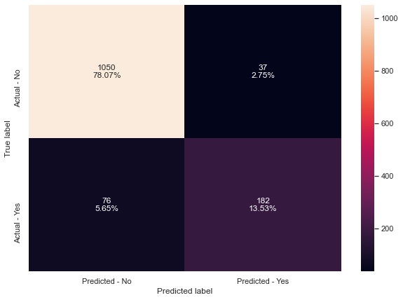

```python
make_confusion_matrix(xgb, y_test)
```

### Observation on Boosting with default parameters:

- XGBoost classifier has better test Recall among these 3 models.
- AdaBoost classifier has least test Recall and test Precision.

## Hyperparameter Tuning

### AdaBoost Classifier

- An AdaBoost classifier is a meta-estimator that begins by fitting a classifier on the original dataset and then fits additional copies of the classifier on the same dataset but where the weights of incorrectly classified instances are adjusted such that subsequent classifiers focus more on difficult cases.
- Some important hyper-paramters are:
  - base_estimator: The base estimator from which the boosted ensemble is built. By default the base estimator is a decision tree with max_depth=1
  - n_estimators: The maximum number of estimators at which boosting is terminated. Default value is 50.
  - learning_rate: Learning rate shrinks the contribution of each classifier by learning_rate. There is a trade-off between learning_rate and n_estimators.

```python
# Choose the type of classifier.
abc_tuned = AdaBoostClassifier(random_state=1)

# Grid of parameters to choose from
## add from article
parameters = {
    # Let's try different max_depth for base_estimator
    "base_estimator": [
        DecisionTreeClassifier(max_depth=1),
        DecisionTreeClassifier(max_depth=2),
        DecisionTreeClassifier(max_depth=3),
    ],
    "n_estimators": np.arange(10, 50, 10),
    "learning_rate": np.arange(0.1, 2, 0.1),
}

# Type of scoring used to compare parameter combinations
acc_scorer = metrics.make_scorer(metrics.recall_score)

# Run the grid search
grid_obj = GridSearchCV(abc_tuned, parameters, scoring=acc_scorer, cv=5)
grid_obj = grid_obj.fit(X_train, y_train)

# Set the clf to the best combination of parameters
abc_tuned = grid_obj.best_estimator_

# Fit the best algorithm to the data.
abc_tuned.fit(X_train, y_train)
```

```
AdaBoostClassifier(base_estimator=DecisionTreeClassifier(max_depth=3),
                   learning_rate=1.5000000000000002, n_estimators=40,
                   random_state=1)
```

```python
# Using above defined function to get accuracy, recall and precision on train and test set
abc_tuned_score = get_metrics_score(abc_tuned)
```

```
Accuracy on training set :  0.9314631813834874
Accuracy on test set :  0.8394052044609666
Recall on training set :  0.7711442786069652
Recall on test set :  0.5232558139534884
Precision on training set :  0.8579335793357934
Precision on test set :  0.5921052631578947
F1 Score on test set :  0.5555555555555556
F1 Score on train set :  0.5555555555555556
```

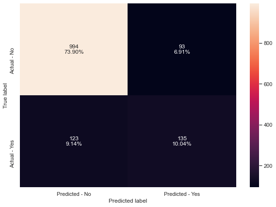

```python
make_confusion_matrix(abc_tuned, y_test)
```

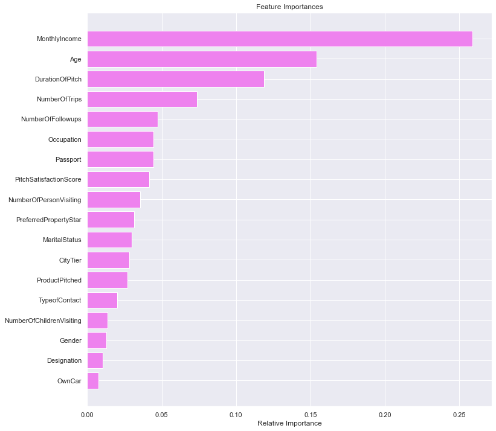

```python
importances = abc_tuned.feature_importances_
indices = np.argsort(importances)
feature_names = list(X.columns)

plt.figure(figsize=(12, 12))
plt.title("Feature Importances")
plt.barh(range(len(indices)), importances[indices], color="violet", align="center")
plt.yticks(range(len(indices)), [feature_names[i] for i in indices])
plt.xlabel("Relative Importance")
plt.show()
```

### Insights

- The model is overfitting the train data as train accuracy is much higher than the test accuracy.
- The model has low test recall. This implies that the model is not good at identifying purchasers.

### Gradient Boosting Classifier

- Most of the hyper-parameters available are same as random forest classifier.
- init: An estimator object that is used to compute the initial predictions. If ‘zero’, the initial raw predictions are set to zero. By default, a DummyEstimator predicting the classes priors is used.
- There is no class_weights parameter in gradient boosting.

```python
gbc_init = GradientBoostingClassifier(
    init=AdaBoostClassifier(random_state=1), random_state=1
)
gbc_init.fit(X_train, y_train)
```

```
GradientBoostingClassifier(init=AdaBoostClassifier(random_state=1),
                           random_state=1)
```

```python
# Using above defined function to get accuracy, recall and precision on train and test set
gbc_init_score = get_metrics_score(gbc_init)
```

```
Accuracy on training set :  0.8941664010200829
Accuracy on test set :  0.8602230483271376
Recall on training set :  0.5124378109452736
Recall on test set :  0.3992248062015504
Precision on training set :  0.8904899135446686
Precision on test set :  0.7573529411764706
F1 Score on test set :  0.5228426395939085
F1 Score on train set :  0.5228426395939085
```

```python
# Choose the type of classifier.
gbc_tuned = GradientBoostingClassifier(
    init=AdaBoostClassifier(random_state=1), random_state=1
)

# Grid of parameters to choose from
## add from article
parameters = {
    "n_estimators": [20, 40, 60, 80],
    "subsample": [0.8, 0.9, 1],
    "max_features": [0.7, 0.8, 0.9, 1],
}

# Type of scoring used to compare parameter combinations
acc_scorer = metrics.make_scorer(metrics.recall_score)

# Run the grid search
grid_obj = GridSearchCV(gbc_tuned, parameters, scoring=acc_scorer, cv=5)
grid_obj = grid_obj.fit(X_train, y_train)

# Set the clf to the best combination of parameters
gbc_tuned = grid_obj.best_estimator_

# Fit the best algorithm to the data.
gbc_tuned.fit(X_train, y_train)
```

```
GradientBoostingClassifier(init=AdaBoostClassifier(random_state=1),
                           max_features=0.7, n_estimators=80, random_state=1,
                           subsample=0.8)
```

```python
# Using above defined function to get accuracy, recall and precision on train and test set
gbc_tuned_score = get_metrics_score(gbc_tuned)
```

```
Accuracy on training set :  0.885559451705451
Accuracy on test set :  0.8602230483271376
Recall on training set :  0.4759535655058043
Recall on test set :  0.38372093023255816
Precision on training set :  0.8696969696969697
Precision on test set :  0.7734375
F1 Score on test set :  0.5129533678756477
F1 Score on train set :  0.5129533678756477
```

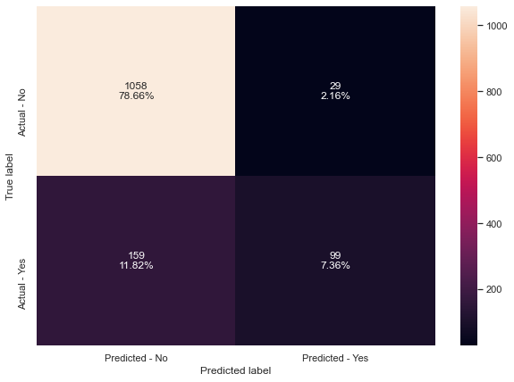

```python
make_confusion_matrix(gbc_tuned, y_test)
```

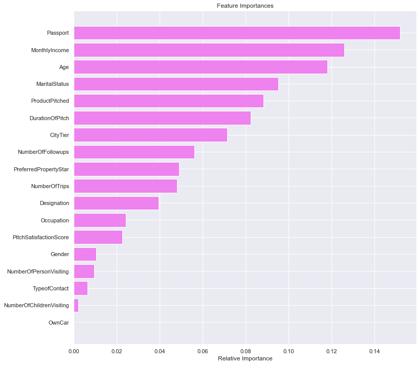

```python
importances = gbc_tuned.feature_importances_
indices = np.argsort(importances)
feature_names = list(X.columns)

plt.figure(figsize=(12, 12))
plt.title("Feature Importances")
plt.barh(range(len(indices)), importances[indices], color="violet", align="center")
plt.yticks(range(len(indices)), [feature_names[i] for i in indices])
plt.xlabel("Relative Importance")
plt.show()
```

### Insights

- The model performance has not increased by much.
- It is better at identifying non-purchasers than identifying purchasers which is the opposite of the result we need.

### XGBoost Classifier

XGBoost has many hyper parameters which can be tuned to increase the model performance.

- scale_pos_weight:Control the balance of positive and negative weights, useful for unbalanced classes. It has range from 0 to infinity.
- subsample: Corresponds to the fraction of observations (the rows) to subsample at each step. By default it is set to 1 meaning that we use all rows.
- colsample_bytree: Corresponds to the fraction of features (the columns) to use.
- colsample_bylevel: The subsample ratio of columns for each level. Columns are subsampled from the set of columns chosen for the current tree.
- colsample_bynode: The subsample ratio of columns for each node (split). Columns are subsampled from the set of columns chosen for the current level.
- max_depth: is the maximum number of nodes allowed from the root to the farthest leaf of a tree.
- learning_rate/eta: Makes the model more robust by shrinking the weights on each step.
- gamma: A node is split only when the resulting split gives a positive reduction in the loss function. Gamma specifies the minimum loss reduction required to make a split.

```python
# Choose the type of classifier.
xgb_tuned = XGBClassifier(random_state=1, eval_metric="logloss")

# Grid of parameters to choose from
## add from
parameters = {
    "n_estimators": [10, 30, 50],
    "scale_pos_weight": [0, 1, 2, 5],
    "subsample": [0.5, 0.7, 0.9, 1],
    "learning_rate": [0.01, 0.1, 0.2, 0.05],
    "gamma": [0, 1, 3],
    "colsample_bytree": [0.5, 0.7, 0.9, 1],
    "colsample_bylevel": [0.5, 0.7, 0.9, 1],
}

# Type of scoring used to compare parameter combinations
acc_scorer = metrics.make_scorer(metrics.recall_score)

# Run the grid search
grid_obj = GridSearchCV(xgb_tuned, parameters, scoring=acc_scorer, cv=5)
grid_obj = grid_obj.fit(X_train, y_train)

# Set the clf to the best combination of parameters
xgb_tuned = grid_obj.best_estimator_

# Fit the best algorithm to the data.
xgb_tuned.fit(X_train, y_train)
```

```
XGBClassifier(base_score=0.5, booster='gbtree', colsample_bylevel=0.9,
              colsample_bynode=1, colsample_bytree=0.5, eval_metric='logloss',
              gamma=3, gpu_id=-1, importance_type='gain',
              interaction_constraints='', learning_rate=0.2, max_delta_step=0,
              max_depth=6, min_child_weight=1, missing=nan,
              monotone_constraints='()', n_estimators=30, n_jobs=8,
              num_parallel_tree=1, random_state=1, reg_alpha=0, reg_lambda=1,
              scale_pos_weight=5, subsample=0.9, tree_method='exact',
              validate_parameters=1, verbosity=None)
```

```python
# Using above defined function to get accuracy, recall and precision on train and test set
xgb_tuned_score = get_metrics_score(xgb_tuned)
```

```
Accuracy on training set :  0.9445329933057061
Accuracy on test set :  0.8676579925650557
Recall on training set :  0.9684908789386402
Recall on test set :  0.7635658914728682
Precision on training set :  0.790257104194858
Precision on test set :  0.6273885350318471
F1 Score on test set :  0.6888111888111889
F1 Score on train set :  0.6888111888111889
```

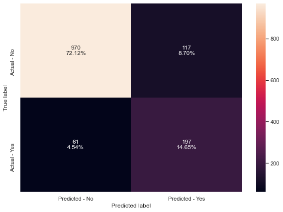

```python
make_confusion_matrix(xgb_tuned, y_test)
```

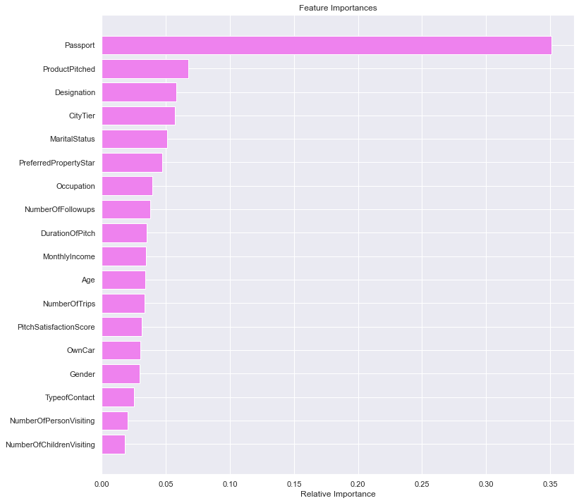

```python
importances = xgb_tuned.feature_importances_
indices = np.argsort(importances)
feature_names = list(X.columns)

plt.figure(figsize=(12, 12))
plt.title("Feature Importances")
plt.barh(range(len(indices)), importances[indices], color="violet", align="center")
plt.yticks(range(len(indices)), [feature_names[i] for i in indices])
plt.xlabel("Relative Importance")
plt.show()
```

### Insights

- Tuned XGBoost has the best Recall performance and not so good precision.
- Considering our use case (maximize Recall to identify potential purchasers for marketing effort), this model performs well.

## Stacking Classifier

- Stacking top 4 model.

```python
estimators = [
    ("Random Forest", rf_estimator),
    ("Gradient Boosting", gbc_tuned),
    ("Decision Tree", dtree_estimator),
]

final_estimator = xgb_tuned

stacking_classifier = StackingClassifier(
    estimators=estimators, final_estimator=final_estimator
)

stacking_classifier.fit(X_train, y_train)
```

```
StackingClassifier(estimators=[('Random Forest',
                                RandomForestClassifier(random_state=1)),
                               ('Gradient Boosting',
                                GradientBoostingClassifier(init=AdaBoostClassifier(random_state=1),
                                                           max_features=0.7,
                                                           n_estimators=80,
                                                           random_state=1,
                                                           subsample=0.8)),
                               ('Decision Tree',
                                DecisionTreeClassifier(class_weight={0: 0.18,
                                                                     1: 0.72},
                                                       max_depth=5,
                                                       max_leaf_nodes=15,
                                                       min_impurity_d...
                                                 eval_metric='logloss', gamma=3,
                                                 gpu_id=-1,
                                                 importance_type='gain',
                                                 interaction_constraints='',
                                                 learning_rate=0.2,
                                                 max_delta_step=0, max_depth=6,
                                                 min_child_weight=1,
                                                 missing=nan,
                                                 monotone_constraints='()',
                                                 n_estimators=30, n_jobs=8,
                                                 num_parallel_tree=1,
                                                 random_state=1, reg_alpha=0,
                                                 reg_lambda=1,
                                                 scale_pos_weight=5,
                                                 subsample=0.9,
                                                 tree_method='exact',
                                                 validate_parameters=1,
                                                 verbosity=None))
```

```
Accuracy on training set :  0.9866114121772394
Accuracy on test set :  0.8907063197026023
Recall on training set :  1.0
Recall on test set :  0.8255813953488372
Precision on training set :  0.9348837209302325
Precision on test set :  0.6761904761904762
F1 Score on test set :  0.7434554973821991
F1 Score on train set :  0.7434554973821991
```

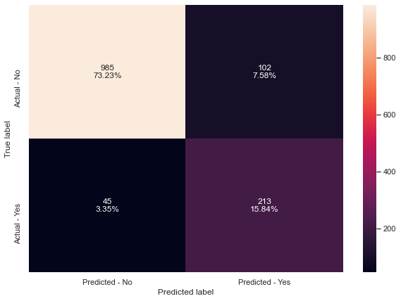

```python
# Calculating different metrics
get_metrics_score(stacking_classifier)

# Creating confusion matrix
make_confusion_matrix(stacking_classifier, y_test)
```

## Comparing all models

```python
# defining list of models
models = [abc, abc_tuned, gbc, gbc_init, gbc_tuned, xgb, xgb_tuned, stacking_classifier]

# defining empty lists to add train and test results
acc_train = []
acc_test = []
recall_train = []
recall_test = []
precision_train = []
precision_test = []
f1Score_train = []
f1Score_test = []

# looping through all the models to get the accuracy, precall and precision scores
for model in models:
    j = get_metrics_score(model, False)
    acc_train.append(np.round(j[0], 2))
    acc_test.append(np.round(j[1], 2))
    recall_train.append(np.round(j[2], 2))
    recall_test.append(np.round(j[3], 2))
    precision_train.append(np.round(j[4], 2))
    precision_test.append(np.round(j[5], 2))
    f1Score_train.append(np.round(j[6], 2))
    f1Score_test.append(np.round(j[7], 2))
```

```python
comparison_frame1 = pd.DataFrame(
    {
        "Model": [
            "AdaBoost with default paramters",
            "AdaBoost Tuned",
            "Gradient Boosting with default parameters",
            "Gradient Boosting with init=AdaBoost",
            "Gradient Boosting Tuned",
            "XGBoost with default parameters",
            "XGBoost Tuned",
            "Stacking Classifier",
        ],
        "Train_Accuracy": acc_train,
        "Test_Accuracy": acc_test,
        "Train_Recall": recall_train,
        "Test_Recall": recall_test,
        "Train_Precision": precision_train,
        "Test_Precision": precision_test,
        "Train_F1Score": f1Score_train,
        "Test_F1Score": f1Score_test,
    }
)
comparison_frame1
```

|  | Model | Train_Accuracy | Test_Accuracy | Train_Recall | Test_Recall | Train_Precision | Test_Precision | Train_F1Score | Test_F1Score |
| --- | --- | --- | --- | --- | --- | --- | --- | --- | --- |
| 0 | AdaBoost with default paramters | 0.86 | 0.84 | 0.39 | 0.32 | 0.73 | 0.64 | 0.51 | 0.43 |
| 1 | AdaBoost Tuned | 0.93 | 0.84 | 0.77 | 0.52 | 0.86 | 0.59 | 0.81 | 0.56 |
| 2 | Gradient Boosting with default parameters | 0.90 | 0.86 | 0.53 | 0.41 | 0.89 | 0.74 | 0.66 | 0.52 |
| 3 | Gradient Boosting with init=AdaBoost | 0.89 | 0.86 | 0.51 | 0.40 | 0.89 | 0.76 | 0.65 | 0.52 |
| 4 | Gradient Boosting Tuned | 0.89 | 0.86 | 0.48 | 0.38 | 0.87 | 0.77 | 0.62 | 0.51 |
| 5 | XGBoost with default parameters | 1.00 | 0.92 | 1.00 | 0.71 | 1.00 | 0.83 | 1.00 | 0.76 |
| 6 | XGBoost Tuned | 0.94 | 0.87 | 0.97 | 0.76 | 0.79 | 0.63 | 0.87 | 0.69 |
| 7 | Stacking Classifier | 0.99 | 0.89 | 1.00 | 0.83 | 0.93 | 0.68 | 0.97 | 0.74 |

```python
frames = [comparison_frame, comparison_frame1]

results = pd.concat(frames)

results
```

|  | Model | Train_Accuracy | Test_Accuracy | Train_Recall | Test_Recall | Train_Precision | Test_Precision | Train_F1Score | Test_F1Score |
| --- | --- | --- | --- | --- | --- | --- | --- | --- | --- |
| 0 | Decision Tree with default parameters | 1.00 | 0.91 | 1.00 | 0.78 | 1.00 | 0.74 | 1.00 | 0.76 |
| 1 | Tuned Decision Tree | 0.78 | 0.75 | 0.72 | 0.66 | 0.45 | 0.41 | 0.55 | 0.51 |
| 2 | Bagging classifier with default parameters | 0.99 | 0.90 | 0.97 | 0.61 | 1.00 | 0.83 | 0.99 | 0.70 |
| 3 | Tuned Bagging Classifier | 1.00 | 0.91 | 1.00 | 0.64 | 1.00 | 0.88 | 1.00 | 0.74 |
| 4 | Bagging classifier with base_estimator=LR | 0.83 | 0.83 | 0.21 | 0.19 | 0.74 | 0.75 | 0.33 | 0.30 |
| 5 | Random Forest with deafult parameters | 1.00 | 0.92 | 1.00 | 0.63 | 1.00 | 0.94 | 1.00 | 0.75 |
| 6 | Tuned Random Forest Classifier | 0.92 | 0.87 | 0.60 | 0.45 | 0.95 | 0.81 | 0.73 | 0.58 |
| 7 | Random Forest with class_weights | 0.91 | 0.86 | 0.71 | 0.57 | 0.78 | 0.68 | 0.74 | 0.62 |
| 0 | AdaBoost with default paramters | 0.86 | 0.84 | 0.39 | 0.32 | 0.73 | 0.64 | 0.51 | 0.43 |
| 1 | AdaBoost Tuned | 0.93 | 0.84 | 0.77 | 0.52 | 0.86 | 0.59 | 0.81 | 0.56 |
| 2 | Gradient Boosting with default parameters | 0.90 | 0.86 | 0.53 | 0.41 | 0.89 | 0.74 | 0.66 | 0.52 |
| 3 | Gradient Boosting with init=AdaBoost | 0.89 | 0.86 | 0.51 | 0.40 | 0.89 | 0.76 | 0.65 | 0.52 |
| 4 | Gradient Boosting Tuned | 0.89 | 0.86 | 0.48 | 0.38 | 0.87 | 0.77 | 0.62 | 0.51 |
| 5 | XGBoost with default parameters | 1.00 | 0.92 | 1.00 | 0.71 | 1.00 | 0.83 | 1.00 | 0.76 |
| 6 | XGBoost Tuned | 0.94 | 0.87 | 0.97 | 0.76 | 0.79 | 0.63 | 0.87 | 0.69 |
| 7 | Stacking Classifier | 0.99 | 0.89 | 1.00 | 0.83 | 0.93 | 0.68 | 0.97 | 0.74 |

```python
results1 = results.copy()

results1["Accuracy_Diff"] = results1["Train_Accuracy"] - results1["Test_Accuracy"]
results1["Recall_Diff"] = results1["Train_Recall"] - results1["Test_Recall"]
results1["Precision_Diff"] = results1["Train_Precision"] - results1["Test_Precision"]

results1.sort_values(by=["Test_Recall", "Train_Recall"], ascending=False)
```

|  | Model | Train_Accuracy | Test_Accuracy | Train_Recall | Test_Recall | Train_Precision | Test_Precision | Train_F1Score | Test_F1Score | Accuracy_Diff | Recall_Diff | Precision_Diff |
| --- | --- | --- | --- | --- | --- | --- | --- | --- | --- | --- | --- | --- |
| 7 | Stacking Classifier | 0.99 | 0.89 | 1.00 | 0.83 | 0.93 | 0.68 | 0.97 | 0.74 | 0.10 | 0.17 | 0.25 |
| 0 | Decision Tree with default parameters | 1.00 | 0.91 | 1.00 | 0.78 | 1.00 | 0.74 | 1.00 | 0.76 | 0.09 | 0.22 | 0.26 |
| 6 | XGBoost Tuned | 0.94 | 0.87 | 0.97 | 0.76 | 0.79 | 0.63 | 0.87 | 0.69 | 0.07 | 0.21 | 0.16 |
| 5 | XGBoost with default parameters | 1.00 | 0.92 | 1.00 | 0.71 | 1.00 | 0.83 | 1.00 | 0.76 | 0.08 | 0.29 | 0.17 |
| 1 | Tuned Decision Tree | 0.78 | 0.75 | 0.72 | 0.66 | 0.45 | 0.41 | 0.55 | 0.51 | 0.03 | 0.06 | 0.04 |
| 3 | Tuned Bagging Classifier | 1.00 | 0.91 | 1.00 | 0.64 | 1.00 | 0.88 | 1.00 | 0.74 | 0.09 | 0.36 | 0.12 |
| 5 | Random Forest with deafult parameters | 1.00 | 0.92 | 1.00 | 0.63 | 1.00 | 0.94 | 1.00 | 0.75 | 0.08 | 0.37 | 0.06 |
| 2 | Bagging classifier with default parameters | 0.99 | 0.90 | 0.97 | 0.61 | 1.00 | 0.83 | 0.99 | 0.70 | 0.09 | 0.36 | 0.17 |
| 7 | Random Forest with class_weights | 0.91 | 0.86 | 0.71 | 0.57 | 0.78 | 0.68 | 0.74 | 0.62 | 0.05 | 0.14 | 0.10 |
| 1 | AdaBoost Tuned | 0.93 | 0.84 | 0.77 | 0.52 | 0.86 | 0.59 | 0.81 | 0.56 | 0.09 | 0.25 | 0.27 |
| 6 | Tuned Random Forest Classifier | 0.92 | 0.87 | 0.60 | 0.45 | 0.95 | 0.81 | 0.73 | 0.58 | 0.05 | 0.15 | 0.14 |
| 2 | Gradient Boosting with default parameters | 0.90 | 0.86 | 0.53 | 0.41 | 0.89 | 0.74 | 0.66 | 0.52 | 0.04 | 0.12 | 0.15 |
| 3 | Gradient Boosting with init=AdaBoost | 0.89 | 0.86 | 0.51 | 0.40 | 0.89 | 0.76 | 0.65 | 0.52 | 0.03 | 0.11 | 0.13 |
| 4 | Gradient Boosting Tuned | 0.89 | 0.86 | 0.48 | 0.38 | 0.87 | 0.77 | 0.62 | 0.51 | 0.03 | 0.10 | 0.10 |
| 0 | AdaBoost with default paramters | 0.86 | 0.84 | 0.39 | 0.32 | 0.73 | 0.64 | 0.51 | 0.43 | 0.02 | 0.07 | 0.09 |
| 4 | Bagging classifier with base_estimator=LR | 0.83 | 0.83 | 0.21 | 0.19 | 0.74 | 0.75 | 0.33 | 0.30 | 0.00 | 0.02 | -0.01 |